# **PCFL 2023: Week 7 wrap-up**

Week 7 is a wrap!

The bye weeks are ongoing y’all. Check your lineups!!

## Last week’s games

[output not shown]

The Peanuts, Hobbits, Sharks, Captain, and Sasquatch all in the Winners column. The Captain and Jaheims only got one point in the standings this week, while the other winners got two.

## Best performances

### Best players overall

Here’s last week’s **10 best performing starters.**

| Player | Position | NFL Team | Points | PCFL Team |
| --- | --- | --- | --- | --- |
| Lamar Jackson | QB | BAL | 33.88 | Middle Earth Hangry Hobbits |
| Patrick Mahomes | QB | KCC | 33.86 | KC Gophers |
| D’Onta Foreman | RB | CHI | 31.50 | Georgia Peanuts |
| Travis Kelce | TE | KCC | 29.90 | Captain Clairvoyant |
| Jordan Addison | RB/WR/TE | MIN | 28.80 | Middle Earth Hangry Hobbits |
| A.J. Brown | WR | PHI | 24.70 | Georgia Peanuts |
| Josh Allen | QB | BUF | 24.30 | The G.O.A.T. |
| Alvin Kamara | RB | NOS | 23.30 | Athens Team Sasquatch |
| Jalen Hurts | QB | PHI | 23.26 | The Seniors |
| Jahmyr Gibbs | RB/WR/TE | DET | 23.10 | Jumpin’ Jaheims |

Jordan Addison had some great catches this week if you haven’t seen them.

### Best players per team

Here’s last week’s top players **on each team.**

| Player | Position | NFL Team | Points | PCFL Team |
| --- | --- | --- | --- | --- |
| Alvin Kamara | RB | NOS | 23.30 | Athens Team Sasquatch |
| Travis Kelce | TE | KCC | 29.90 | Captain Clairvoyant |
| D’Onta Foreman | RB | CHI | 31.50 | Georgia Peanuts |
| Jahmyr Gibbs | RB/WR/TE | DET | 23.10 | Jumpin’ Jaheims |
| Patrick Mahomes | QB | KCC | 33.86 | KC Gophers |
| Lamar Jackson | QB | BAL | 33.88 | Middle Earth Hangry Hobbits |
| Gus Edwards | BE | BAL | 20.90 | Pigskin on the Gridiron |
| Darren Waller | TE | NYG | 19.30 | Southern Sharks |
| Josh Allen | QB | BUF | 24.30 | The G.O.A.T. |
| Jalen Hurts | QB | PHI | 23.26 | The Seniors |

### Best bench

Who won the **best scoring bench** award last week?

| Team | Bench points |
| --- | --- |
| The G.O.A.T. | 75.78 |
| Jumpin’ Jaheims | 72.44 |
| Captain Clairvoyant | 49.86 |
| Southern Sharks | 44.80 |
| Middle Earth Hangry Hobbits | 42.50 |
| KC Gophers | 40.40 |
| The Seniors | 35.57 |
| Pigskin on the Gridiron | 30.50 |
| Athens Team Sasquatch | 25.70 |
| Georgia Peanuts | 25.30 |

Here’s the season’s bench standings:

| Team | Bench points |
| --- | --- |
| Georgia Peanuts | 450.48 |
| Southern Sharks | 417.40 |
| Athens Team Sasquatch | 411.08 |
| Jumpin’ Jaheims | 399.44 |
| The Seniors | 371.68 |
| Middle Earth Hangry Hobbits | 364.44 |
| Pigskin on the Gridiron | 361.77 |
| Captain Clairvoyant | 359.68 |
| KC Gophers | 344.20 |
| The G.O.A.T. | 319.12 |

Bye weeks hurt my Peanuts this week, but we still have a comfortable lead. Sharks are lurking as always, though.

### Best optimized lineups

I compared the actual starting lineups for each team to the hypothetical *best* starting lineup the owner could have started. The table below shows the actual points the team scored, the top score they could have had, and an “optimization” percentage that compares to the two.

| PCFL Team | Actual points | Best lineup | Optimization rate |
| --- | --- | --- | --- |
| Middle Earth Hangry Hobbits | 128.38 | 135.38 | 95% |
| The Seniors | 97.76 | 103.06 | 95% |
| Southern Sharks | 115.46 | 125.96 | 92% |
| Athens Team Sasquatch | 112.04 | 125.54 | 89% |
| Captain Clairvoyant | 100.26 | 119.06 | 84% |
| Georgia Peanuts | 114.96 | 139.26 | 83% |
| Jumpin’ Jaheims | 112.26 | 135.24 | 83% |
| KC Gophers | 82.06 | 104.46 | 79% |
| Pigskin on the Gridiron | 66.40 | 89.10 | 75% |
| The G.O.A.T. | 70.20 | 100.40 | 70% |

For the *whole season*, here’s a graph of actual points scored vs. optimized points given the roster.

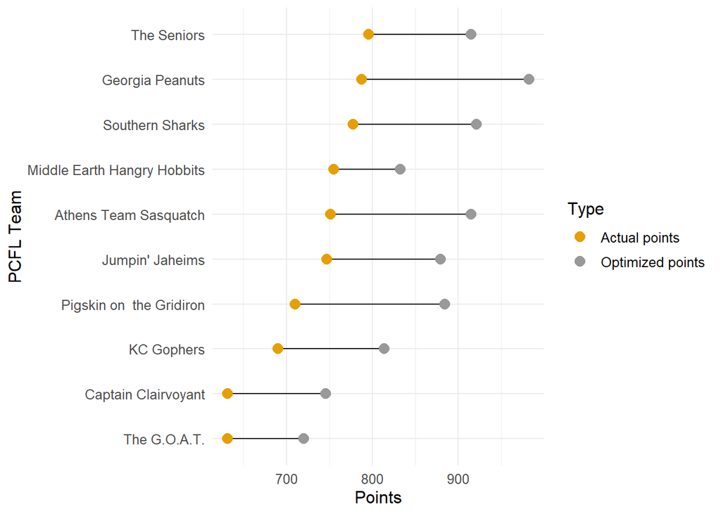

### Point distribution by position

Here’s a breakdown of point contribution by position by team so far this season.

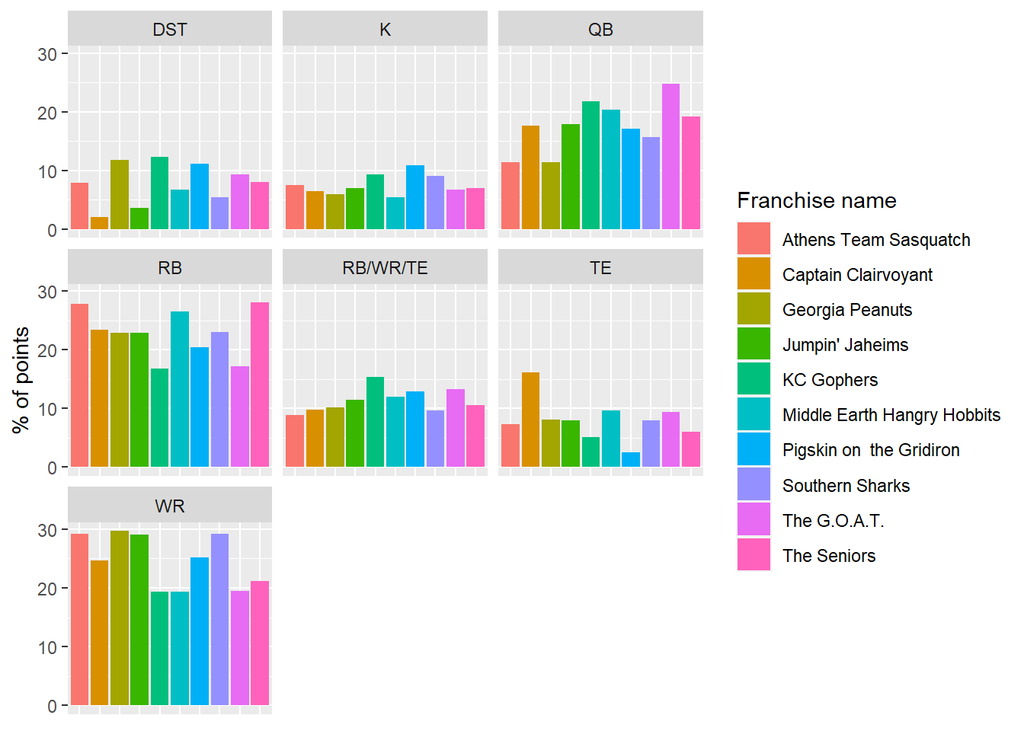

Fun facts:

- Richard is the only owner to have more than 10% of his points from the kicker position.
- Brian has gotten 13 TOTAL points from his DST position ALL SEASON.
- Robbie is having his usual resurgence, but is virtually tied with me for lowest points from the QB position (11.4%).

### Best pick-ups

There were 8 players added last week. Which was the **best pick-ups**?

| PCFL Team | Player | NFL Team | Position | Points |
| --- | --- | --- | --- | --- |
| Captain Clairvoyant | Jonathan Taylor | IND | RB | 19.5 |
| Pigskin on the Gridiron | Jordan Love | GBP | QB | 15.3 |
| Athens Team Sasquatch | Giants D/ST | NYG | DST | 15.0 |
| Georgia Peanuts | Jaxon Smith-Njigba | SEA | WR | 14.3 |
| KC Gophers | Tyler Allgeier | ATL | RB | 12.7 |
| Captain Clairvoyant | Drake London | ATL | WR | 8.4 |
| Athens Team Sasquatch | Amari Cooper | CLE | WR | 3.2 |
| Jumpin’ Jaheims | Rams D/ST | LAR | DST | 2.0 |

### Best team performances

Here’s a list of the **top five scoring performances** so far this season.

| PCFL Team | Week | Score | Result |
| --- | --- | --- | --- |
| Middle Earth Hangry Hobbits | 2 | 167.18 | W |
| Jumpin’ Jaheims | 4 | 149.98 | W |
| Georgia Peanuts | 4 | 148.64 | W |
| The Seniors | 3 | 146.88 | W |
| Athens Team Sasquatch | 6 | 142.70 | W |

Scott still hanging tight at the top.

## Looking ahead

### League standings

| PCFL Team | Division | Points scored | Avg points | Avg last 3 | W | L | Team points |
| --- | --- | --- | --- | --- | --- | --- | --- |
| Southern Sharks | Hot Dish | 777.62 | 111.09 | 99.07 | 4 | 3 | 10 |
| Georgia Peanuts | Hot Dish | 787.82 | 112.55 | 120.40 | 4 | 3 | 9 |
| Athens Team Sasquatch | Grits | 751.62 | 107.37 | 124.21 | 5 | 2 | 9 |
| The Seniors | Hot Dish | 795.89 | 113.70 | 96.23 | 3 | 4 | 8 |
| Middle Earth Hangry Hobbits | Hot Dish | 754.98 | 107.85 | 108.07 | 3 | 4 | 7 |
| Pigskin on the Gridiron | Grits | 710.40 | 101.49 | 72.43 | 4 | 3 | 7 |
| Jumpin’ Jaheims | Grits | 746.92 | 106.70 | 103.16 | 3 | 4 | 6 |
| KC Gophers | Hot Dish | 689.18 | 98.45 | 93.61 | 3 | 4 | 6 |
| The G.O.A.T. | Grits | 631.49 | 90.21 | 99.66 | 3 | 4 | 5 |
| Captain Clairvoyant | Grits | 631.80 | 90.26 | 100.88 | 3 | 4 | 3 |

Sarah and I are now 1 and 2, but Robbie (our league champion 3 of the last 4 seasons, I believe) has inched up to third.

### If the season ended today…

It’s Sarah, me, Robbie, and Erin/Trav right now. Scott and Richard are one point off the pace.

### This week’s matchups

| Team 1 | Team 2 |
| --- | --- |
| Athens Team Sasquatch (Avg. last 3: 124.21) | Southern Sharks (Avg. last 3: 99.07) |
| Captain Clairvoyant (Avg. last 3: 100.88) | Middle Earth Hangry Hobbits (Avg. last 3: 108.07) |
| Georgia Peanuts (Avg. last 3: 120.4) | Jumpin’ Jaheims (Avg. last 3: 103.16) |
| KC Gophers (Avg. last 3: 93.61) | Pigskin on the Gridiron (Avg. last 3: 72.43) |
| The G.O.A.T. (Avg. last 3: 99.66) | The Seniors (Avg. last 3: 96.23) |

Big game for Sarah and Robbie this week.

Good luck, y’all!